# Paper or Download?

Lupita Woods

05/03/2022

# Introduction

> This project takes a look at data from Amazon’s top 50 bestselling books between the years 2009 up to early 2022, with the purpose of pointing at anything significant if detected, and in general, to describe what the dataset shows.

# The Data

### Source:

- **“Amazon’s Top 50 Bestselling Books 2009 - 2022”** from kaggle.com

```r
summary(books_data)
```

```
##      Name              Author           User.Rating      Reviews
##  Length:700         Length:700         Min.   :3.30   Min.   :    37
##  Class :character   Class :character   1st Qu.:4.50   1st Qu.:  4987
##  Mode  :character   Mode  :character   Median :4.70   Median : 10284
##                                        Mean   :4.64   Mean   : 19255
##                                        3rd Qu.:4.80   3rd Qu.: 23358
##                                        Max.   :4.90   Max.   :208917
##      Price            Year         Genre
##  Min.   :  0.0   Min.   :2009   Length:700
##  1st Qu.:  7.0   1st Qu.:2012   Class :character
##  Median : 11.0   Median :2016   Mode  :character
##  Mean   : 12.7   Mean   :2016
##  3rd Qu.: 15.0   3rd Qu.:2019
##  Max.   :105.0   Max.   :2022
```

# Metadata

Columns:  
- Name: Book title.  
- Author: Book author.  
- User Rating: Average user rating(out of 5 stars, 0 - 5.0). - Reviews: Number of reviews.  
- Price: Rounded(whole numbers)  
- Year: Year that the title made it to the top 50 bestselling list.  
- Genre: Book type(fiction/non-fiction).

# Libraries Used

- tydyverse
- ggplot2
- wesanderson

# Data Preparation

- Clean data.
- Titles issues.
- User rating, reviews and price, as of data collection time.

# Questions

# Data visualization

Is there any preference between Fiction vs. Non-Fiction overall?

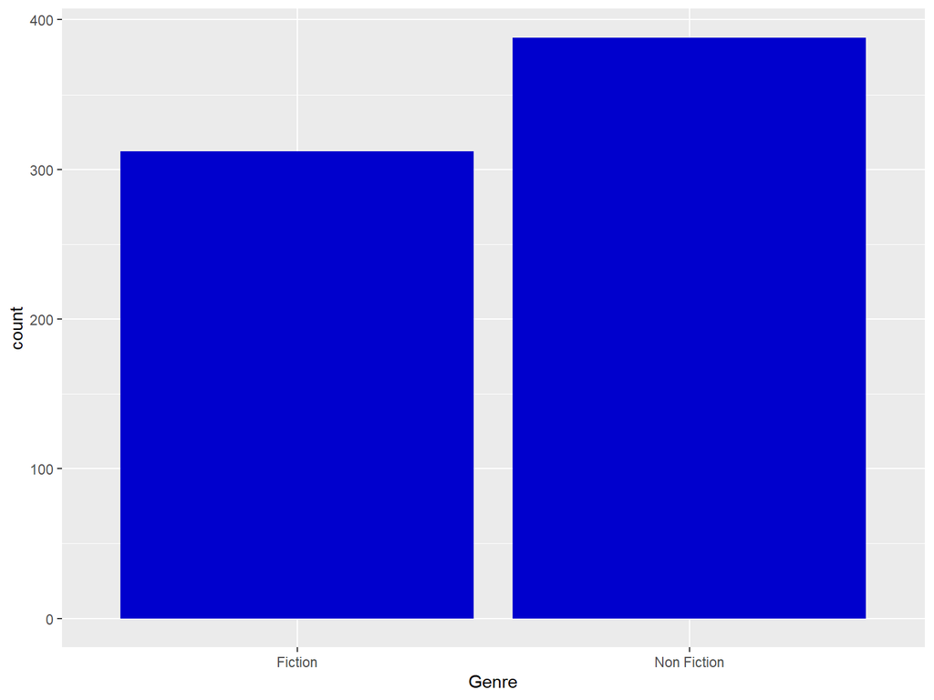

# Data visualization…

Does higher user rating indicate specific genre?

With a boxplot:

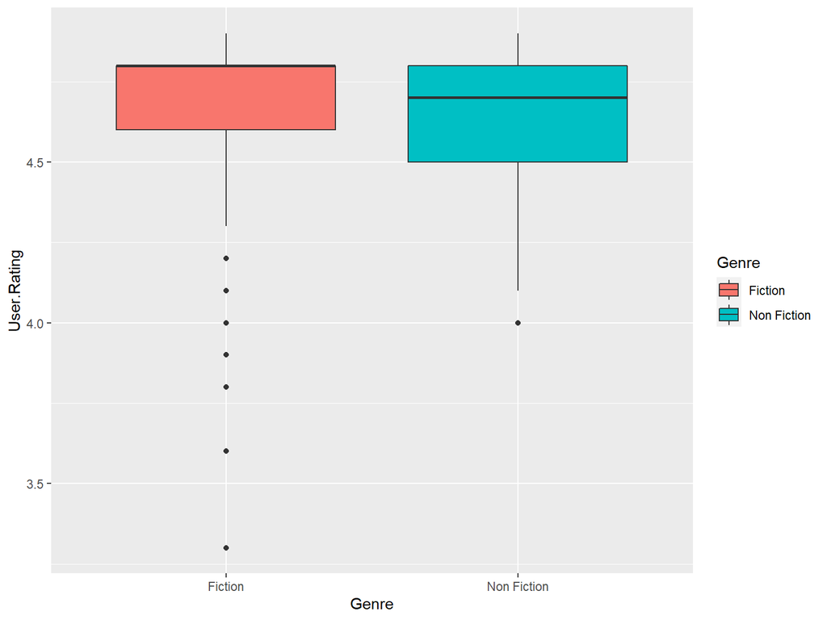

With an overlaid density plot:

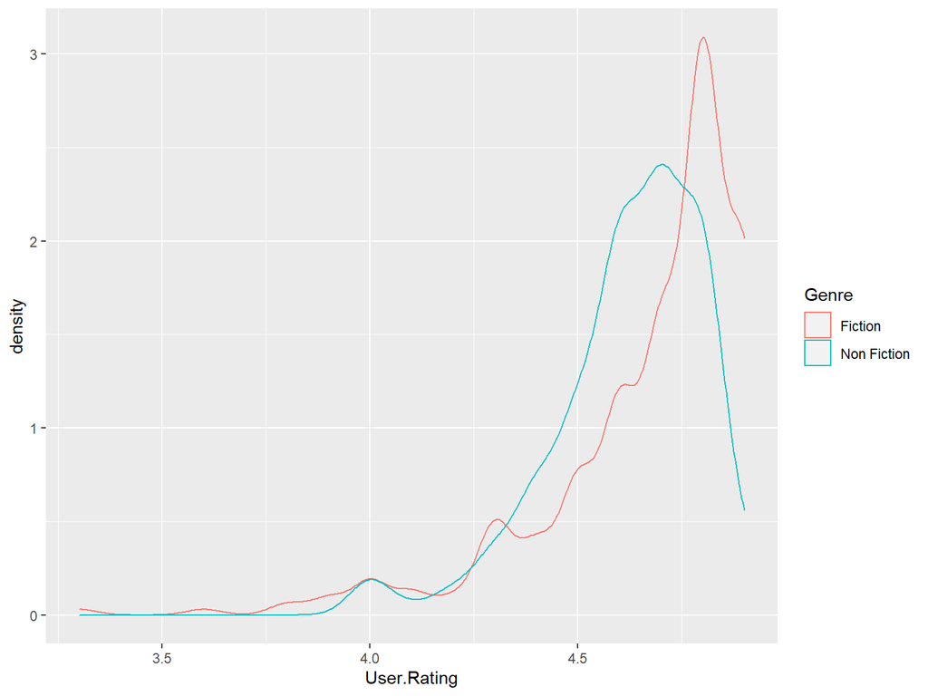

# Data Visualization…

Did any of the genres sell more during the pandemic?

With a boxplot:

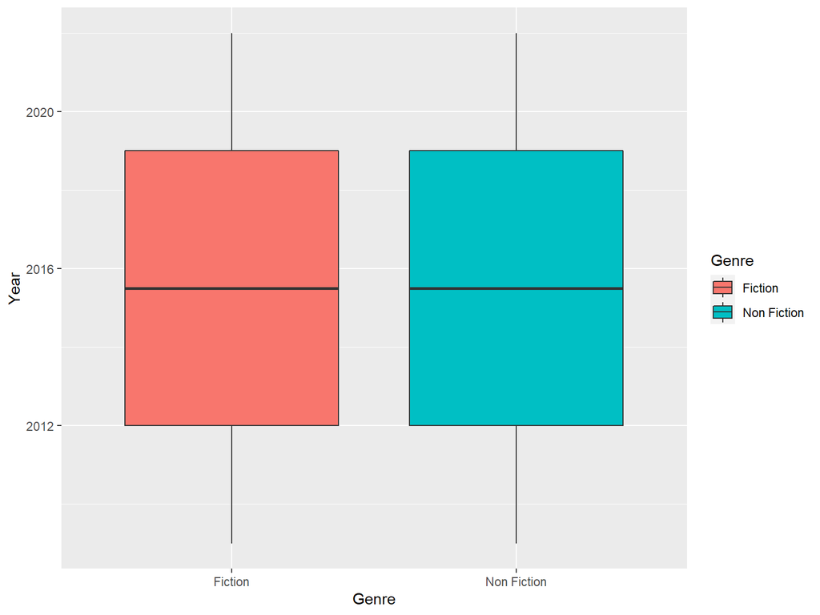

With an overlaid density plot:

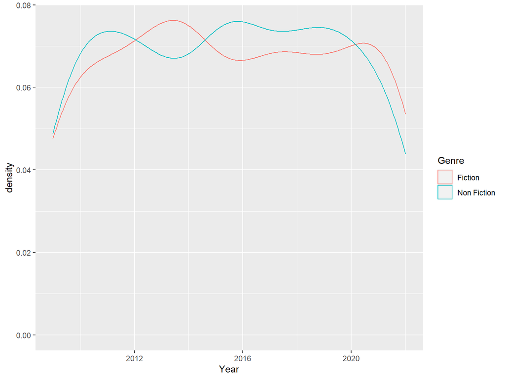

# Data Visualization…

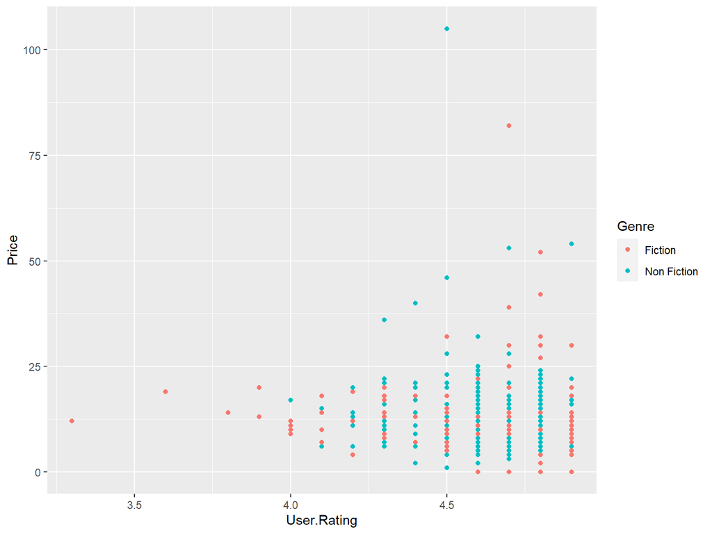

# Summary

- The dataset is small.
- There is only one categorical variable.
- There is some indication of fluctuation since the pandemic started.